# EMD-Circular

Flora Timney

2025-05-23

### Introduction

This script is to analyse the outputs of the colour overlay of perceived motion direction from the EMD model plugin of ImageJ. This script must be proceeded by lateral tracking using the SAM-2 pipeline I developed to get the lateral masks (to apply colour Treatments) and centroid tracks (to infer real motion direction). Then in python script, the colour treatments of averaging out the luminance of just background (‘bg’) pixels or both (‘both’) background and fish pixels separately to artificially make them plain. These colour treatments allowed me to separate out the effects of body patterns above and beyond simply being fish-shaped againt a plain background. These pre-processed clip frames were then run through the EMD model using a custom Macro script I designed “2_Batch_EMD.ijm” and the output is a table of Up, Down, Left, Right detector values.

### Set up

Initialise R environment, set working directory, clear workspace, load in functions and packages, and set plot theme.

[output not shown]

### 1. Load in and organise data

### 2. Analyze real and perceived motion direction in each clip

### 3. Plotting motion:

Looping through all clips and creating plots of direction and magnitude of motion

```r
# Create output directories
dir.create("Figures/Motion_plots", recursive = TRUE, showWarnings = FALSE)
dir.create("Figures/Motion_plots/Combined", recursive = TRUE, showWarnings = FALSE)

# Get all unique ClipNames from FullClipName
unique_clips <- unique(EMDOverlay_clipsummary$ClipName)

# Loop through each unique ClipName
for (clip in unique_clips) {
  message("▶️ Processing: ", clip)

  # Generate and save all plots
  plots <- plot_motion(
    clipname     = clip,
    frame_data   = EMDOverlay_frames,
    summary_data = EMDOverlay_clipsummary,
    output_dir   = "Figures/Motion_plots",
    save_circular  = TRUE,
    save_direction = TRUE,
    save_magnitude = TRUE
  )

  # Combine the three saved plots
  combine_motion_plots_by_clipname(
    clipname    = clip,
    input_dir   = "Figures/Motion_plots",
    output_dir  = "Figures/Motion_plots/Combined"
  )
}
```

## 4. Statistical analysis of Direction and Magnitude

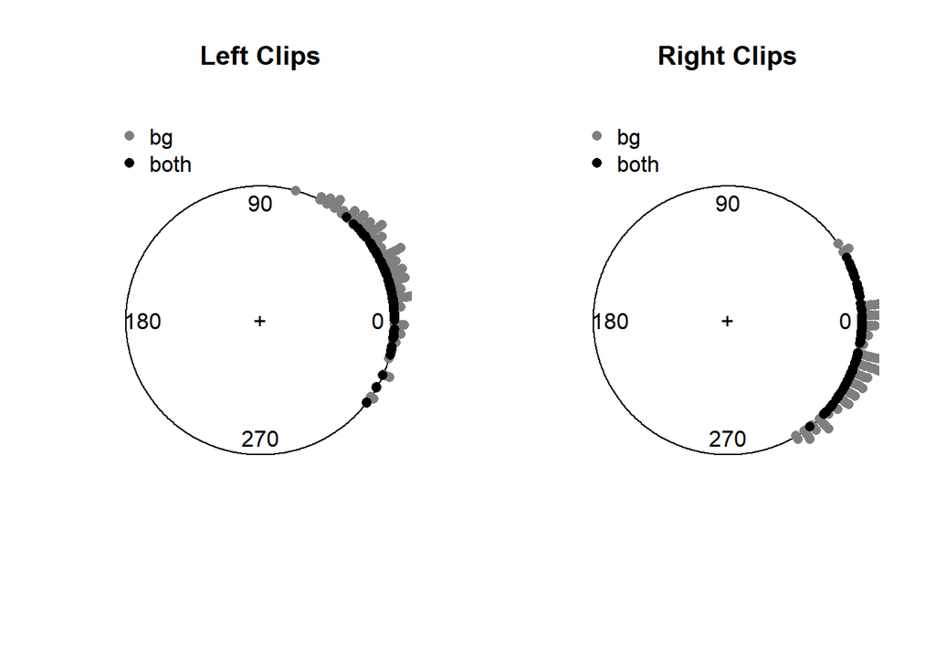

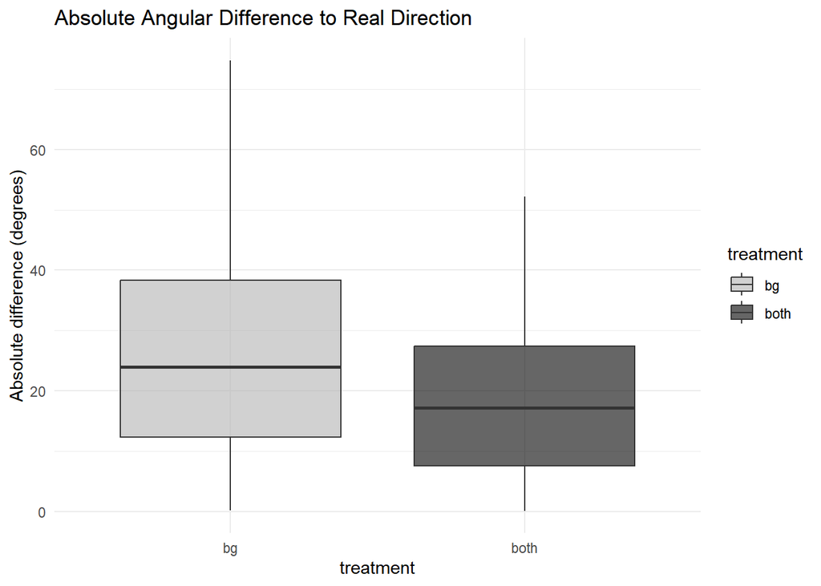

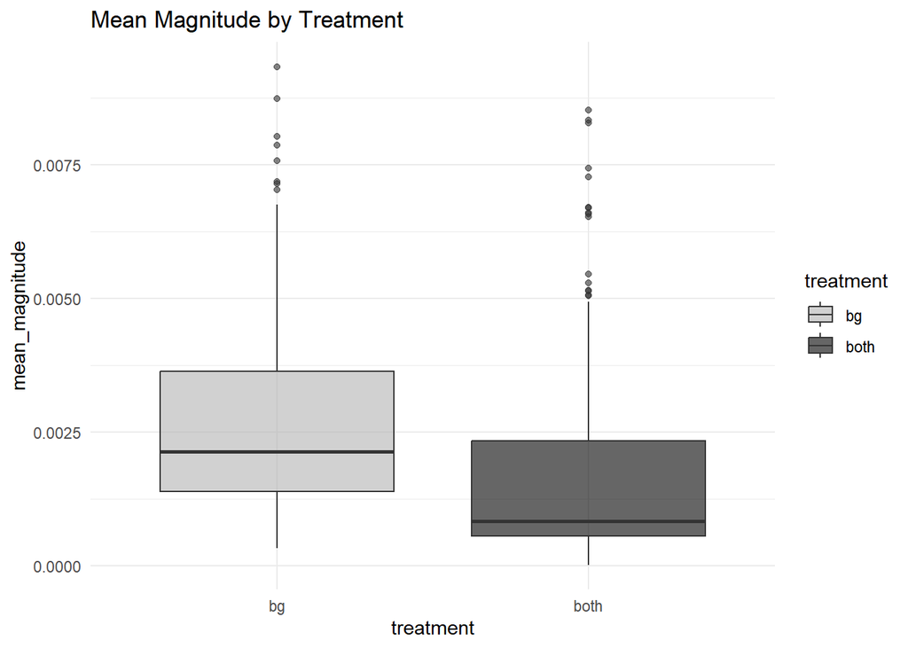

Plotting for individual clips

```r
plots <- plot_motion(clipname = "Botia_lohachata_C_10_2",
                     frame_data   = EMDOverlay_frames,
                     summary_data = EMDOverlay_clipsummary,
                     output_dir   = "Figures/Plots")

# Now you can view them like this:
plots$direction_plot
plots$magnitude_plot
plots$circular_plot()  # call as a function to render circular plot in viewer

combine_motion_plots_by_clipname("Botia_lohachata_C_10_2",
                                 input_dir = "Figures/Plots",
                                 output_dir = "Figures/Plots/Combined")
```

[output not shown]